# 🍽️ Recipe Recommendation System

### Content-Based Filtering using TF-IDF + Cosine Similarity

This notebook builds a user-facing recipe recommender that takes:

- Ingredients the user has on hand
- Priority ingredients to heavily boost (e.g. the protein)
- Max prep time
- Max cook time
- Cuisine preference
- Minimum ingredient match threshold

And returns the top matching recipes ranked by relevance.

## Cell 1 — Install & Import Libraries

```python
# Run this cell first to install any missing libraries
# imbalanced-learn is needed for SMOTE oversampling in Experiment 3
!pip install pandas scikit-learn numpy matplotlib imbalanced-learn
```

```python
import pandas as pd
import numpy as np
from sklearn.feature_extraction.text import TfidfVectorizer
from sklearn.metrics.pairwise import cosine_similarity
from sklearn.linear_model import LogisticRegression
from sklearn.naive_bayes import MultinomialNB
from sklearn.model_selection import train_test_split
from sklearn.metrics import precision_score, recall_score, f1_score, classification_report
from imblearn.over_sampling import SMOTE
import matplotlib.pyplot as plt
import warnings
warnings.filterwarnings('ignore')

# Show full URLs in output tables without truncation
pd.set_option('display.max_colwidth', None)

print('✅ Libraries loaded successfully')
```

```
✅ Libraries loaded successfully
```

## Cell 2 — Load & Preview the Dataset

```python
# Load dataset — make sure allrecipes_dataset.csv is in the same folder as this notebook
df = pd.read_csv('allrecipes_dataset.csv')

print(f'Dataset shape: {df.shape}')
print(f'Cuisines found: {sorted(df["cuisine"].unique())}')
df.head()
```

```
Dataset shape: (1746, 9)
Cuisines found: ['Brazilian', 'Cajun_Creole', 'Chinese', 'Cuban', 'French', 'German', 'Greek', 'Indian', 'Italian', 'Japanese', 'Mediterranean', 'Mexican', 'Peruvian', 'Soul_Food', 'Southern', 'Tex_Mex', 'Thai', 'Vietnamese']
```

|  | title | cuisine | ingredients | prep_time_min | cook_time_min | total_time_min | rating | servings | url |
| --- | --- | --- | --- | --- | --- | --- | --- | --- | --- |
| 0 | Mexican Rice | Mexican | 3 tablespoons vegetable oil \| 1 cup uncooked long-grain rice \| 1/4 cup chopped onion \| 1 teaspoon garlic salt \| 1/2 teaspoon ground cumin \| 2 cups chicken broth \| 1/2 cup tomato sauce | 5.0 | 30.0 | 35.0 | 4.7 | 4 servings | https://www.allrecipes.com/recipe/27072/mexican-rice-ii/ |
| 1 | Rich Mexican Corn | Mexican | 1 (8 ounce) package cream cheese \| 1/2 cup butter \| 1/2 cup milk \| 1 (16 ounce) package frozen corn \| 8 fresh jalapeno peppers, diced \| 1 red bell pepper, diced | 15.0 | 45.0 | 60.0 | 4.6 | 8 servings | https://www.allrecipes.com/recipe/66657/rich-mexican-corn/ |
| 2 | Quick and Easy Mexican Chicken | Mexican | cooking spray \| 4 skinless, boneless chicken breasts \| 1 clove garlic, minced \| 1 pinch salt \| 1 pinch ground black pepper \| 1 pinch ground cumin \| 1 cup salsa \| 1 cup shredded Cheddar cheese | 15.0 | 25.0 | 40.0 | 4.5 | 4 servings | https://www.allrecipes.com/recipe/8597/quick-and-easy-mexican-chicken/ |
| 3 | Simple Mexican Rice | Mexican | 2 tablespoons vegetable oil \| 1 onion, chopped \| 1 teaspoon minced garlic \| 1 teaspoon chili powder \| 1 tablespoon ground cumin \| 1 cup uncooked short-grain white rice \| 1 3/4 cups chicken broth… | 10.0 | 40.0 | 50.0 | 4.2 | 5 servings | https://www.allrecipes.com/recipe/88095/simple-mexican-rice/ |
| 4 | Mexican Pizza | Mexican | 1/2 pound ground beef \| 1 medium onion, diced \| 1 clove garlic, minced \| 1 tablespoon chili powder \| 1 teaspoon ground cumin \| 1/2 teaspoon paprika \| 1/2 teaspoon salt \| 1/2 teaspoon black pepp… | 20.0 | 25.0 | 45.0 | 4.7 | 8 servings | https://www.allrecipes.com/recipe/53075/jimmys-mexican-pizza/ |

## Cell 3 — Clean & Preprocess the Data

```python
# ── Remove duplicates caused by scraper pause/resume ─────────────────────────
# URL is the unique identifier for each recipe
before = len(df)
df = df.drop_duplicates(subset=['url'])
after = len(df)
print(f'🧹 Removed {before - after} duplicate recipes ({after} remaining)')

# ── Drop rows missing critical fields ─────────────────────────────────────────
df = df.dropna(subset=['ingredients', 'title'])

# ── Convert time and rating columns to numbers ────────────────────────────────
df['prep_time_min']  = pd.to_numeric(df['prep_time_min'],  errors='coerce')
df['cook_time_min']  = pd.to_numeric(df['cook_time_min'],  errors='coerce')
df['total_time_min'] = pd.to_numeric(df['total_time_min'], errors='coerce')
df['rating']         = pd.to_numeric(df['rating'],         errors='coerce')

# ── Fill missing values with median so recipes still appear in results ────────
df['prep_time_min'].fillna(df['prep_time_min'].median(),   inplace=True)
df['cook_time_min'].fillna(df['cook_time_min'].median(),   inplace=True)
df['total_time_min'].fillna(df['total_time_min'].median(), inplace=True)
df['rating'].fillna(df['rating'].median(),                 inplace=True)

# ── Normalize cuisine names for consistent matching ───────────────────────────
df['cuisine'] = df['cuisine'].str.strip().str.lower()

# ── Clean ingredients into a single lowercase string for TF-IDF ──────────────
df['ingredients_clean'] = (
    df['ingredients']
    .str.lower()
    .str.replace(r'[^a-z\s|]', '', regex=True)
    .str.replace('|', ' ', regex=False)
)

# Reset index so the cosine similarity matrix stays aligned with the dataframe
df = df.reset_index(drop=True)

print(f'✅ Cleaned dataset: {len(df)} recipes across {df["cuisine"].nunique()} cuisines')
print(f'Time range — prep: {df["prep_time_min"].min():.0f}–{df["prep_time_min"].max():.0f} min | '
      f'cook: {df["cook_time_min"].min():.0f}–{df["cook_time_min"].max():.0f} min')
```

```
🧹 Removed 0 duplicate recipes (1746 remaining)
✅ Cleaned dataset: 1746 recipes across 18 cuisines
Time range — prep: 1–510 min | cook: 1–1500 min
```

## Cell 4 — Build the TF-IDF Matrix

TF-IDF weighs ingredients by how unique they are across all recipes. Common ingredients (salt, water) get lower weight. Unique ones (miso, plantain) get higher weight. This is the foundation of our content-based filtering approach.

```python
# Build TF-IDF matrix on ingredient text
tfidf = TfidfVectorizer(
    ngram_range=(1, 2),   # captures single words AND pairs e.g. 'black beans', 'olive oil'
    min_df=2,             # ignore ingredients appearing in fewer than 2 recipes
    max_df=0.95,          # ignore ingredients in more than 95% of recipes (too generic)
    stop_words='english'  # remove generic English words
)

tfidf_matrix = tfidf.fit_transform(df['ingredients_clean'])

print(f'✅ TF-IDF matrix: {tfidf_matrix.shape[0]} recipes × {tfidf_matrix.shape[1]} ingredient terms')
```

```
✅ TF-IDF matrix: 1746 recipes × 6175 ingredient terms
```

## Cell 5 — Recommendation Function (Experiment 1 Baseline)

**How scoring works:**

- User inputs are vectorized using the same TF-IDF vocabulary
- Priority ingredients are repeated in the input vector to boost their weight
- Cosine similarity measures how closely each recipe matches the user's ingredients
- Final relevance score = 80% ingredient match + 20% rating
- Recipes below the minimum match threshold are filtered out entirely

**Ablation toggles** allow Experiment 2 to remove one feature at a time without rewriting the function.

```python
def recommend_recipes(
    user_ingredients,
    max_prep_time=None,
    max_cook_time=None,
    cuisine=None,
    top_n=5,
    priority_ingredients=None,  # ingredients to heavily boost (e.g. your protein)
    priority_boost=5.0,         # how many times to repeat priority ingredients
    min_match=5.0,              # minimum ingredient match % — filters out irrelevant recipes
    use_rating=True,            # ablation toggle: set False to remove rating
    use_prep_time=True,         # ablation toggle: set False to remove prep filter
    use_cook_time=True,         # ablation toggle: set False to remove cook filter
    use_priority=True           # ablation toggle: set False to remove priority boost
):
    """
    Recommend recipes based on user inputs.
    Ablation toggles allow Experiment 2 to remove one feature at a time.
    """

    # ── Step 1: Hard filters — time and cuisine ───────────────────────────────
    filtered = df.copy()

    if use_prep_time and max_prep_time is not None:
        filtered = filtered[filtered['prep_time_min'] <= max_prep_time]

    if use_cook_time and max_cook_time is not None:
        filtered = filtered[filtered['cook_time_min'] <= max_cook_time]

    if cuisine is not None:
        filtered = filtered[filtered['cuisine'] == cuisine.strip().lower()]

    if filtered.empty:
        print('⚠️  No recipes match your time/cuisine filters. Try relaxing your constraints.')
        return None

    # ── Step 2: Build boosted user input vector ───────────────────────────────
    all_ingredients = [i.strip().lower() for i in user_ingredients.split(',')]

    if priority_ingredients and use_priority:
        priority_list = [p.strip().lower() for p in priority_ingredients.split(',')]
        print(f'🔺 Boosting priority ingredients x{int(priority_boost)}: {priority_list}')
    else:
        priority_list = []

    # Repeat priority ingredients to increase their TF-IDF weight
    boosted_parts = []
    for ingredient in all_ingredients:
        if ingredient in priority_list:
            boosted_parts.extend([ingredient] * int(priority_boost))
        else:
            boosted_parts.append(ingredient)

    user_vector = tfidf.transform([' '.join(boosted_parts)])

    # ── Step 3: Cosine similarity against filtered recipes ────────────────────
    filtered_indices = filtered.index.tolist()
    filtered_tfidf   = tfidf_matrix[filtered_indices]
    similarities     = cosine_similarity(user_vector, filtered_tfidf).flatten()

    # ── Step 4: Apply minimum match threshold ────────────────────────────────
    similarity_pct  = similarities * 100
    above_threshold = similarity_pct >= min_match

    if not any(above_threshold):
        print(f'⚠️  No recipes scored above the {min_match}% match threshold.')
        print('    Try lowering min_match or adding more ingredients.')
        return None

    filtered       = filtered.iloc[above_threshold]
    similarities   = similarities[above_threshold]
    similarity_pct = similarity_pct[above_threshold]

    # ── Step 5: Normalize ratings — set to 0 if ablated ──────────────────────
    if use_rating:
        max_r        = df['rating'].max()
        min_r        = df['rating'].min()
        norm_ratings = (filtered['rating'].values - min_r) / (max_r - min_r if max_r != min_r else 1)
    else:
        norm_ratings = np.zeros(len(filtered))

    # ── Step 6: Weighted relevance score ─────────────────────────────────────
    # Ingredient match drives recommendations (80%), rating is tiebreaker (20%)
    INGREDIENT_WEIGHT = 0.80
    RATING_WEIGHT     = 0.20
    relevance_scores  = INGREDIENT_WEIGHT * similarities + RATING_WEIGHT * norm_ratings

    # ── Step 7: Build and return results dataframe ────────────────────────────
    results = filtered.copy()
    results['ingredient_match'] = similarity_pct.round(1)
    results['relevance_score']  = (relevance_scores * 100).round(1)

    results = (
        results
        .sort_values('relevance_score', ascending=False)
        .head(top_n)
    )

    display_cols = [
        'title', 'cuisine', 'prep_time_min', 'cook_time_min',
        'rating', 'ingredient_match', 'relevance_score', 'url'
    ]
    return results[display_cols].reset_index(drop=True)

print('✅ Recommender function ready!')
```

```
✅ Recommender function ready!
```

## Cell 6 — Try It Out!

Edit the inputs below and run the cell to get personalized recipe recommendations.

**Tips:**

- Set `PRIORITY_INGREDIENTS` to your protein or most important ingredient
- Set `CUISINE` to `None` to search across all cuisines
- Lower `MIN_MATCH` if you're getting no results; raise it to filter out weak matches
- Increase `PRIORITY_BOOST` (e.g. 8 or 10) if your key ingredient still isn't dominating

```python
# ── ✏️  EDIT THESE INPUTS ─────────────────────────────────────────────────────

MY_INGREDIENTS       = 'cilantro, garlic, lemon, olive oil, onion, salt, pepper, steak, turkey, cucumber, rice, beans, potato'
PRIORITY_INGREDIENTS = 'steak'   # set to None for no boost
MAX_PREP_TIME        = 20          # minutes — set to None for no limit
MAX_COOK_TIME        = 30          # minutes — set to None for no limit
CUISINE              = None        # e.g. 'italian', 'mexican', 'thai' — None = any
HOW_MANY             = 10          # number of results to show
MIN_MATCH            = 5.0         # minimum ingredient match % (0 = no filter)

# ── Run the recommender ───────────────────────────────────────────────────────
results = recommend_recipes(
    user_ingredients     = MY_INGREDIENTS,
    max_prep_time        = MAX_PREP_TIME,
    max_cook_time        = MAX_COOK_TIME,
    cuisine              = CUISINE,
    top_n                = HOW_MANY,
    priority_ingredients = PRIORITY_INGREDIENTS,
    min_match            = MIN_MATCH
)

if results is not None:
    print(f'\n🍽️  Top {HOW_MANY} recipes for your ingredients:')
    print(f'   Ingredients : {MY_INGREDIENTS}')
    print(f'   Priority    : {PRIORITY_INGREDIENTS}')
    print(f'   Max prep    : {MAX_PREP_TIME} min | Max cook: {MAX_COOK_TIME} min')
    print(f'   Cuisine     : {CUISINE or "Any"} | Min match: {MIN_MATCH}%')
    print()
    display(results)
```

```
🔺 Boosting priority ingredients x5: ['steak']

🍽️  Top 10 recipes for your ingredients:
   Ingredients : cilantro, garlic, lemon, olive oil, onion, salt, pepper, steak, turkey, cucumber, rice, beans, potato
   Priority    : steak
   Max prep    : 20 min | Max cook: 30 min
   Cuisine     : Any | Min match: 5.0%
```

|  | title | cuisine | prep_time_min | cook_time_min | rating | ingredient_match | relevance_score | url |
| --- | --- | --- | --- | --- | --- | --- | --- | --- |
| 0 | Bistec Encebollado (Cuban Steak and Onions) | cuban | 10.0 | 25.0 | 5.0 | 14.7 | 31.8 | https://www.allrecipes.com/recipe/284258/bistec-encebollado-cuban-steak-and-onions/ |
| 1 | Mediterranean Stuffed Swordfish | mediterranean | 15.0 | 20.0 | 4.6 | 16.2 | 30.3 | https://www.allrecipes.com/recipe/152264/mediterranean-stuffed-swordfish/ |
| 2 | Steak Fingers | french | 10.0 | 15.0 | 3.9 | 21.7 | 30.0 | https://www.allrecipes.com/recipe/20618/steak-fingers/ |
| 3 | Chef John's Grilled Mojo Beef | cuban | 10.0 | 8.0 | 4.8 | 12.8 | 28.9 | https://www.allrecipes.com/recipe/254948/chef-johns-grilled-mojo-beef/ |
| 4 | Cuban Marinated Steak | cuban | 15.0 | 15.0 | 4.7 | 13.5 | 28.8 | https://www.allrecipes.com/recipe/232415/cuban-marinated-steak/ |
| 5 | Sweet Teriyaki Beef Skewers | japanese | 15.0 | 6.0 | 4.8 | 11.8 | 28.1 | https://www.allrecipes.com/recipe/231664/sweet-teriyaki-beef-skewers/ |
| 6 | Beef Kushiyaki | japanese | 15.0 | 10.0 | 4.7 | 12.3 | 27.8 | https://www.allrecipes.com/recipe/218058/beef-kushiyaki/ |
| 7 | Thai Beef | thai | 15.0 | 5.0 | 4.6 | 12.7 | 27.5 | https://www.allrecipes.com/recipe/234642/thai-beef/ |
| 8 | Super-Simple, Super-Spicy Mongolian Beef | chinese | 15.0 | 10.0 | 4.6 | 12.1 | 27.0 | https://www.allrecipes.com/recipe/148831/super-simple-super-spicy-mongolian-beef/ |
| 9 | Chinese Pepper Steak | chinese | 15.0 | 15.0 | 4.6 | 11.1 | 26.2 | https://www.allrecipes.com/recipe/172704/chinese-pepper-steak/ |

## Cell 7 — Dataset Visualizations

Useful charts for your poster presentation.

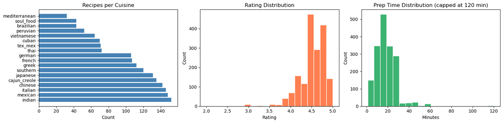

```
Total recipes: 1746
       prep_time_min  cook_time_min  rating
count         1746.0         1746.0  1746.0
mean            18.3           60.7     4.5
std             17.6          103.9     0.3
min              1.0            1.0     2.0
25%             10.0           20.0     4.4
50%             15.0           30.0     4.5
75%             20.0           50.0     4.7
max            510.0         1500.0     5.0
```

```python
fig, axes = plt.subplots(1, 3, figsize=(16, 4))

# Recipes per cuisine
cuisine_counts = df['cuisine'].value_counts()
axes[0].barh(cuisine_counts.index, cuisine_counts.values, color='steelblue')
axes[0].set_title('Recipes per Cuisine')
axes[0].set_xlabel('Count')

# Rating distribution
axes[1].hist(df['rating'].dropna(), bins=20, color='coral', edgecolor='white')
axes[1].set_title('Rating Distribution')
axes[1].set_xlabel('Rating')
axes[1].set_ylabel('Count')

# Prep time distribution (capped at 120 min for readability)
axes[2].hist(df['prep_time_min'].clip(upper=120), bins=20, color='mediumseagreen', edgecolor='white')
axes[2].set_title('Prep Time Distribution (capped at 120 min)')
axes[2].set_xlabel('Minutes')
axes[2].set_ylabel('Count')

plt.tight_layout()
plt.show()

print(f'Total recipes: {len(df)}')
print(df[['prep_time_min', 'cook_time_min', 'rating']].describe().round(1))
```

## Cell 8 — Evaluate: Precision Score (Baseline)

A recipe is considered truly relevant if:

1. Its `ingredient_match` score is >= `match_threshold` (Option A — strict scoring bar)
2. It contains the priority ingredient (Option C — rule 1)
3. It contains at least `min_additional` other user ingredients (Option C — rule 2)

```python
def evaluate_precision(results, user_ingredients, priority_ingredients=None,
                       match_threshold=11.5, min_additional=2):
    """
    Combined evaluation using Option A + Option C.

    A recipe is considered truly relevant if:
      1. ingredient_match >= match_threshold  (Option A)
      2. contains the priority ingredient     (Option C rule 1)
      3. contains >= min_additional others    (Option C rule 2)
    """
    if results is None or results.empty:
        print('No results to evaluate.')
        return 0.0

    all_ingredients   = [i.strip().lower() for i in user_ingredients.split(',')]
    priority_list     = [p.strip().lower() for p in priority_ingredients.split(',')]\
                        if priority_ingredients else []
    other_ingredients = [i for i in all_ingredients if i not in priority_list]
    relevant_count    = 0

    print(f'\n📊 Evaluating {len(results)} recommendations:')
    print(f'   Threshold  : {match_threshold}% match score')
    print(f'   Must contain priority ingredient(s): {priority_list}')
    print(f'   Must contain at least {min_additional} other ingredients from your list')
    print()

    for _, row in results.iterrows():
        # Look up full ingredients from main df using URL as the key
        recipe_ingredients = df.loc[df['url'] == row['url'], 'ingredients_clean'].values[0]

        passes_threshold   = row['ingredient_match'] >= match_threshold
        contains_priority  = all(p in recipe_ingredients for p in priority_list) if priority_list else True
        additional_matches = sum(1 for i in other_ingredients if i in recipe_ingredients)
        passes_additional  = additional_matches >= min_additional
        is_relevant        = passes_threshold and contains_priority and passes_additional

        status = '✅' if is_relevant else '❌'
        print(f'  {status} {row["title"][:45]:<45} | match: {row["ingredient_match"]}% | '
              f'priority: {"✓" if contains_priority else "✗"} | other matches: {additional_matches}')

        if is_relevant:
            relevant_count += 1

    precision = relevant_count / len(results)
    print(f'\n🎯 Precision: {precision:.2f} ({relevant_count}/{len(results)} recipes truly relevant)')
    return precision


# ── Run baseline evaluation ───────────────────────────────────────────────────
results = recommend_recipes(
    user_ingredients     = MY_INGREDIENTS,
    max_prep_time        = MAX_PREP_TIME,
    max_cook_time        = MAX_COOK_TIME,
    cuisine              = CUISINE,
    top_n                = HOW_MANY,
    priority_ingredients = PRIORITY_INGREDIENTS,
    min_match            = MIN_MATCH
)

BASELINE_PRECISION = evaluate_precision(
    results              = results,
    user_ingredients     = MY_INGREDIENTS,
    priority_ingredients = PRIORITY_INGREDIENTS,
    match_threshold      = 11.5,
    min_additional       = 2
)
print(f'\n📌 Baseline precision saved: {BASELINE_PRECISION:.2f}')
```

```
🔺 Boosting priority ingredients x5: ['steak']

📊 Evaluating 10 recommendations:
   Threshold  : 11.5% match score
   Must contain priority ingredient(s): ['steak']
   Must contain at least 2 other ingredients from your list

  ✅ Bistec Encebollado (Cuban Steak and Onions)   | match: 14.7% | priority: ✓ | other matches: 5
  ✅ Mediterranean Stuffed Swordfish               | match: 16.2% | priority: ✓ | other matches: 3
  ✅ Steak Fingers                                 | match: 21.7% | priority: ✓ | other matches: 2
  ✅ Chef John's Grilled Mojo Beef                 | match: 12.8% | priority: ✓ | other matches: 6
  ❌ Cuban Marinated Steak                         | match: 13.5% | priority: ✓ | other matches: 0
  ❌ Sweet Teriyaki Beef Skewers                   | match: 11.8% | priority: ✓ | other matches: 1
  ✅ Beef Kushiyaki                                | match: 12.3% | priority: ✓ | other matches: 2
  ❌ Thai Beef                                     | match: 12.7% | priority: ✓ | other matches: 1
  ✅ Super-Simple, Super-Spicy Mongolian Beef      | match: 12.1% | priority: ✓ | other matches: 3
  ❌ Chinese Pepper Steak                          | match: 11.1% | priority: ✓ | other matches: 2

🎯 Precision: 0.60 (6/10 recipes truly relevant)

📌 Baseline precision saved: 0.60
```

## Experiment 2 — Feature Ablation Study

We systematically remove one feature at a time and measure how precision changes. This tells us which features actually contribute to recommendation quality.

Features tested:

- **No Rating** — rating weight set to zero, only ingredient match drives score
- **No Prep Time Filter** — prep time constraint is ignored
- **No Cook Time Filter** — cook time constraint is ignored
- **No Priority Boost** — all ingredients treated equally, no boosting

```
=======================================================
  Running: Baseline (All Features)
=======================================================
🔺 Boosting priority ingredients x5: ['steak']

📊 Evaluating 10 recommendations:
   Threshold  : 11.5% match score
   Must contain priority ingredient(s): ['steak']
   Must contain at least 2 other ingredients from your list

  ✅ Bistec Encebollado (Cuban Steak and Onions)   | match: 14.7% | priority: ✓ | other matches: 5
  ✅ Mediterranean Stuffed Swordfish               | match: 16.2% | priority: ✓ | other matches: 3
  ✅ Steak Fingers                                 | match: 21.7% | priority: ✓ | other matches: 2
  ✅ Chef John's Grilled Mojo Beef                 | match: 12.8% | priority: ✓ | other matches: 6
  ❌ Cuban Marinated Steak                         | match: 13.5% | priority: ✓ | other matches: 0
  ❌ Sweet Teriyaki Beef Skewers                   | match: 11.8% | priority: ✓ | other matches: 1
  ✅ Beef Kushiyaki                                | match: 12.3% | priority: ✓ | other matches: 2
  ❌ Thai Beef                                     | match: 12.7% | priority: ✓ | other matches: 1
  ✅ Super-Simple, Super-Spicy Mongolian Beef      | match: 12.1% | priority: ✓ | other matches: 3
  ❌ Chinese Pepper Steak                          | match: 11.1% | priority: ✓ | other matches: 2

🎯 Precision: 0.60 (6/10 recipes truly relevant)

=======================================================
  Running: No Rating
=======================================================
🔺 Boosting priority ingredients x5: ['steak']

📊 Evaluating 10 recommendations:
   Threshold  : 11.5% match score
   Must contain priority ingredient(s): ['steak']
   Must contain at least 2 other ingredients from your list

  ✅ Steak Fingers                                 | match: 21.7% | priority: ✓ | other matches: 2
  ✅ Mediterranean Stuffed Swordfish               | match: 16.2% | priority: ✓ | other matches: 3
  ✅ Bistec Encebollado (Cuban Steak and Onions)   | match: 14.7% | priority: ✓ | other matches: 5
  ❌ Cuban Marinated Steak                         | match: 13.5% | priority: ✓ | other matches: 0
  ✅ Chef John's Grilled Mojo Beef                 | match: 12.8% | priority: ✓ | other matches: 6
  ❌ Thai Beef                                     | match: 12.7% | priority: ✓ | other matches: 1
  ✅ Asian Fire Meat                               | match: 12.4% | priority: ✓ | other matches: 3
```

[output cut: 62 more lines]

```
  ❌ Cuban-Style Yuca                              | match: 16.5% | priority: ✗ | other matches: 5
  ❌ Vegan Sweet Potato Chickpea Curry             | match: 12.2% | priority: ✗ | other matches: 5
  ❌ Bistec Encebollado (Cuban Steak and Onions)   | match: 9.4% | priority: ✓ | other matches: 5
  ❌ Chef John's Beans and Greens                  | match: 10.9% | priority: ✗ | other matches: 6
  ❌ Kentucky Wonder Beans                         | match: 10.8% | priority: ✗ | other matches: 5
  ❌ Greek Pasta Salad                             | match: 11.5% | priority: ✗ | other matches: 7
  ✅ Mediterranean Stuffed Swordfish               | match: 12.2% | priority: ✓ | other matches: 3
  ❌ Tomatillo Soup                                | match: 11.0% | priority: ✗ | other matches: 6
  ❌ Italian Shrimp and Scallop Risotto            | match: 9.7% | priority: ✗ | other matches: 6

🎯 Precision: 0.10 (1/10 recipes truly relevant)

=======================================================
📊 EXPERIMENT 2 — ABLATION STUDY SUMMARY
=======================================================
```

|  | Configuration | Precision | Avg Ingredient Match (%) | Recipes Returned |
| --- | --- | --- | --- | --- |
| 0 | Baseline (All Features) | 0.6 | 13.9 | 10 |
| 1 | No Rating | 0.8 | 14.1 | 10 |
| 2 | No Prep Time Filter | 0.7 | 14.0 | 10 |
| 3 | No Cook Time Filter | 0.7 | 14.7 | 10 |
| 4 | No Priority Boost | 0.1 | 11.8 | 10 |

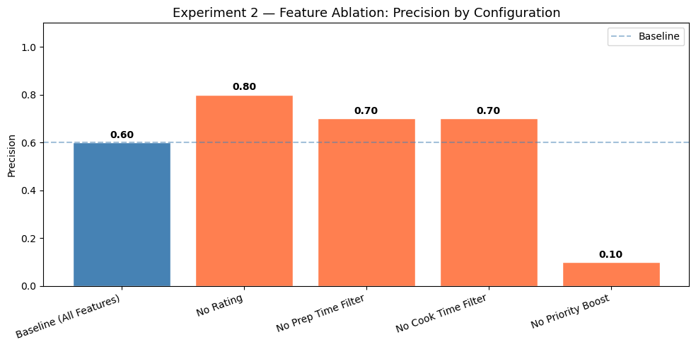

```
💾 Chart saved as experiment2_ablation.png
```

```python
# ── Ablation configurations ───────────────────────────────────────────────────
# Each entry removes exactly one feature from the full model
ablation_configs = [
    {
        'name':         'Baseline (All Features)',
        'use_rating':   True,
        'use_prep':     True,
        'use_cook':     True,
        'use_priority': True,
    },
    {
        'name':         'No Rating',
        'use_rating':   False,
        'use_prep':     True,
        'use_cook':     True,
        'use_priority': True,
    },
    {
        'name':         'No Prep Time Filter',
        'use_rating':   True,
        'use_prep':     False,
        'use_cook':     True,
        'use_priority': True,
    },
    {
        'name':         'No Cook Time Filter',
        'use_rating':   True,
        'use_prep':     True,
        'use_cook':     False,
        'use_priority': True,
    },
    {
        'name':         'No Priority Boost',
        'use_rating':   True,
        'use_prep':     True,
        'use_cook':     True,
        'use_priority': False,
    },
]

ablation_results = []

for config in ablation_configs:
    print(f"\n{'='*55}")
    print(f"  Running: {config['name']}")
    print(f"{'='*55}")

    res = recommend_recipes(
        user_ingredients     = MY_INGREDIENTS,
        max_prep_time        = MAX_PREP_TIME,
        max_cook_time        = MAX_COOK_TIME,
        cuisine              = CUISINE,
        top_n                = HOW_MANY,
        priority_ingredients = PRIORITY_INGREDIENTS,
        min_match            = MIN_MATCH,
        use_rating           = config['use_rating'],
        use_prep_time        = config['use_prep'],
        use_cook_time        = config['use_cook'],
        use_priority         = config['use_priority'],
    )

    if res is not None:
        avg_match = res['ingredient_match'].mean()
        precision = evaluate_precision(
            results              = res,
            user_ingredients     = MY_INGREDIENTS,
            priority_ingredients = PRIORITY_INGREDIENTS,
            match_threshold      = 11.5,
            min_additional       = 2
        )
        ablation_results.append({
            'Configuration':           config['name'],
            'Precision':               round(precision, 2),
            'Avg Ingredient Match (%)': round(avg_match, 1),
            'Recipes Returned':        len(res)
        })
    else:
        ablation_results.append({
            'Configuration':           config['name'],
            'Precision':               0.0,
            'Avg Ingredient Match (%)': 0.0,
            'Recipes Returned':        0
        })

# ── Summary table ─────────────────────────────────────────────────────────────
ablation_df = pd.DataFrame(ablation_results)
print(f"\n{'='*55}")
print('📊 EXPERIMENT 2 — ABLATION STUDY SUMMARY')
print(f"{'='*55}")
display(ablation_df)

# ── Bar chart ─────────────────────────────────────────────────────────────────
fig, ax = plt.subplots(figsize=(10, 5))
colors = ['steelblue' if i == 0 else 'coral' for i in range(len(ablation_df))]
bars = ax.bar(ablation_df['Configuration'], ablation_df['Precision'], color=colors, edgecolor='white')

for bar, val in zip(bars, ablation_df['Precision']):
    ax.text(bar.get_x() + bar.get_width()/2, bar.get_height() + 0.01,
            f'{val:.2f}', ha='center', va='bottom', fontweight='bold')

ax.set_title('Experiment 2 — Feature Ablation: Precision by Configuration', fontsize=13)
ax.set_ylabel('Precision')
ax.set_ylim(0, 1.1)
ax.axhline(y=BASELINE_PRECISION, color='steelblue', linestyle='--', alpha=0.5, label='Baseline')
ax.legend()
plt.xticks(rotation=20, ha='right')
plt.tight_layout()
plt.savefig('experiment2_ablation.png', dpi=150, bbox_inches='tight')
plt.show()
print('💾 Chart saved as experiment2_ablation.png')
```

## Experiment 3 — Binary Classification with SMOTE

We reframe the recommendation problem as a binary classification task.

**Label definition:** A recipe is labeled **Recommended (1)** if:

- It matches at least 30% of the user's available ingredients AND
- Its total time is within the user's time constraints

Otherwise it is labeled **Not Recommended (0)**.

**Class imbalance fix:** We use SMOTE (Synthetic Minority Oversampling Technique) to balance the training set. SMOTE generates synthetic positive examples by interpolating between real ones — this gives the model enough signal to learn from the minority class. Critically, SMOTE is only applied to the **training set**, never the test set, so our evaluation remains honest.

We train and compare two classifiers:

- **Logistic Regression** — a linear model that predicts probability of recommendation
- **Naive Bayes** — a probabilistic model that works well with text/ingredient data

Evaluation metrics: Precision, Recall, F1-Score

```python
# ── Step 1: Generate binary labels ───────────────────────────────────────────
# Lowered from 0.60 to 0.30 to generate more positive examples
# This gives Naive Bayes enough signal to learn from

def compute_match_score(recipe_ingredients, user_ingredients_list):
    """Compute what fraction of user ingredients appear in the recipe."""
    matches = sum(1 for ing in user_ingredients_list if ing in recipe_ingredients)
    return matches / len(user_ingredients_list) if user_ingredients_list else 0

user_ing_list  = [i.strip().lower() for i in MY_INGREDIENTS.split(',')]
max_total_time = (MAX_PREP_TIME or 9999) + (MAX_COOK_TIME or 9999)

df['match_score'] = df['ingredients_clean'].apply(
    lambda x: compute_match_score(str(x), user_ing_list)
)

# ── CHANGE: threshold lowered from 0.60 to 0.30 ──────────────────────────────
# At 0.60, only 171 recipes were labeled Recommended — too few for Naive Bayes
# At 0.30, we get more positive examples for a more balanced training set
MATCH_THRESHOLD = 0.30

df['label'] = (
    (df['match_score'] >= MATCH_THRESHOLD) &
    (df['total_time_min'] <= max_total_time)
).astype(int)

print(f'Label distribution:')
print(df['label'].value_counts())
print(f'\nRecommended (1): {df["label"].sum()} recipes')
print(f'Not Recommended (0): {(df["label"]==0).sum()} recipes')
```

```
Label distribution:
label
0    1354
1     392
Name: count, dtype: int64

Recommended (1): 392 recipes
Not Recommended (0): 1354 recipes
```

```python
# ── Step 2: Split data and apply SMOTE to training set only ──────────────────
# IMPORTANT: SMOTE is only ever applied to the TRAINING set
# Applying it to the test set would give fake/inflated evaluation results

X = tfidf_matrix
y = df['label'].values

# 80% train, 20% test — stratified so both classes appear in both splits
X_train, X_test, y_train, y_test = train_test_split(
    X, y, test_size=0.2, random_state=42, stratify=y
)

# ── Apply SMOTE to balance the training set ───────────────────────────────────
# SMOTE creates synthetic minority class examples by interpolating between
# existing positive examples — this helps the model learn the minority class
# We convert to dense array first because SMOTE requires it
smote = SMOTE(random_state=42)
X_train_balanced, y_train_balanced = smote.fit_resample(
    X_train.toarray(), y_train
)

print(f'Before SMOTE — Train set: {X_train.shape[0]} recipes ({y_train.sum()} recommended)')
print(f'After SMOTE  — Train set: {X_train_balanced.shape[0]} recipes ({y_train_balanced.sum()} recommended)')
print(f'Test set (unchanged): {X_test.shape[0]} recipes ({y_test.sum()} recommended)')
```

```
Before SMOTE — Train set: 1396 recipes (313 recommended)
After SMOTE  — Train set: 2166 recipes (1083 recommended)
Test set (unchanged): 350 recipes (79 recommended)
```

```python
# ── Step 3: Train and evaluate Logistic Regression ───────────────────────────
print('Training Logistic Regression...')
lr_model = LogisticRegression(max_iter=1000, class_weight='balanced', random_state=42)
lr_model.fit(X_train_balanced, y_train_balanced)
lr_preds = lr_model.predict(X_test)

lr_precision = precision_score(y_test, lr_preds, zero_division=0)
lr_recall    = recall_score(y_test, lr_preds, zero_division=0)
lr_f1        = f1_score(y_test, lr_preds, zero_division=0)

print(f'\n📊 Logistic Regression Results:')
print(f'   Precision : {lr_precision:.2f}')
print(f'   Recall    : {lr_recall:.2f}')
print(f'   F1 Score  : {lr_f1:.2f}')
print(f'\nDetailed Report:')
print(classification_report(y_test, lr_preds, target_names=['Not Recommended', 'Recommended']))
```

```
Training Logistic Regression...

📊 Logistic Regression Results:
   Precision : 0.48
   Recall    : 0.56
   F1 Score  : 0.51

Detailed Report:
                 precision    recall  f1-score   support

Not Recommended       0.86      0.82      0.84       271
    Recommended       0.48      0.56      0.51        79

       accuracy                           0.76       350
      macro avg       0.67      0.69      0.68       350
   weighted avg       0.78      0.76      0.77       350
```

```python
# ── Step 4: Train and evaluate Naive Bayes ────────────────────────────────────
# MultinomialNB works well with TF-IDF features (text/ingredient data)
# With SMOTE applied, it now has enough positive examples to learn from
print('Training Naive Bayes...')
nb_model = MultinomialNB(alpha=1.0)
nb_model.fit(X_train_balanced, y_train_balanced)
nb_preds = nb_model.predict(X_test)

nb_precision = precision_score(y_test, nb_preds, zero_division=0)
nb_recall    = recall_score(y_test, nb_preds, zero_division=0)
nb_f1        = f1_score(y_test, nb_preds, zero_division=0)

print(f'\n📊 Naive Bayes Results:')
print(f'   Precision : {nb_precision:.2f}')
print(f'   Recall    : {nb_recall:.2f}')
print(f'   F1 Score  : {nb_f1:.2f}')
print(f'\nDetailed Report:')
print(classification_report(y_test, nb_preds, target_names=['Not Recommended', 'Recommended']))
```

```
Training Naive Bayes...

📊 Naive Bayes Results:
   Precision : 0.38
   Recall    : 0.72
   F1 Score  : 0.50

Detailed Report:
                 precision    recall  f1-score   support

Not Recommended       0.89      0.66      0.76       271
    Recommended       0.38      0.72      0.50        79

       accuracy                           0.67       350
      macro avg       0.64      0.69      0.63       350
   weighted avg       0.77      0.67      0.70       350
```

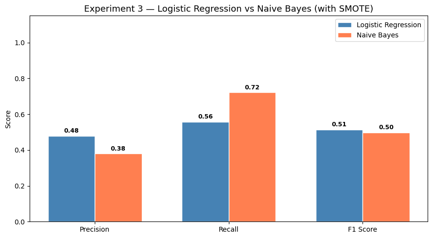

```
💾 Chart saved as experiment3_classification.png

📊 EXPERIMENT 3 — CLASSIFICATION SUMMARY
```

|  | Model | Precision | Recall | F1 Score |
| --- | --- | --- | --- | --- |
| 0 | Logistic Regression | 0.48 | 0.56 | 0.51 |
| 1 | Naive Bayes | 0.38 | 0.72 | 0.50 |

```python
# ── Step 5: Compare classifiers visually ─────────────────────────────────────
metrics   = ['Precision', 'Recall', 'F1 Score']
lr_scores = [lr_precision, lr_recall, lr_f1]
nb_scores = [nb_precision, nb_recall, nb_f1]

x     = np.arange(len(metrics))
width = 0.35

fig, ax = plt.subplots(figsize=(9, 5))
bars1 = ax.bar(x - width/2, lr_scores, width, label='Logistic Regression', color='steelblue', edgecolor='white')
bars2 = ax.bar(x + width/2, nb_scores, width, label='Naive Bayes',         color='coral',     edgecolor='white')

for bar in bars1:
    ax.text(bar.get_x() + bar.get_width()/2, bar.get_height() + 0.01,
            f'{bar.get_height():.2f}', ha='center', va='bottom', fontsize=9, fontweight='bold')
for bar in bars2:
    ax.text(bar.get_x() + bar.get_width()/2, bar.get_height() + 0.01,
            f'{bar.get_height():.2f}', ha='center', va='bottom', fontsize=9, fontweight='bold')

ax.set_title('Experiment 3 — Logistic Regression vs Naive Bayes (with SMOTE)', fontsize=13)
ax.set_ylabel('Score')
ax.set_ylim(0, 1.15)
ax.set_xticks(x)
ax.set_xticklabels(metrics)
ax.legend()
plt.tight_layout()
plt.savefig('experiment3_classification.png', dpi=150, bbox_inches='tight')
plt.show()
print('💾 Chart saved as experiment3_classification.png')

# ── Final summary table ───────────────────────────────────────────────────────
summary_df = pd.DataFrame({
    'Model':     ['Logistic Regression', 'Naive Bayes'],
    'Precision': [round(lr_precision, 2), round(nb_precision, 2)],
    'Recall':    [round(lr_recall, 2),    round(nb_recall, 2)],
    'F1 Score':  [round(lr_f1, 2),        round(nb_f1, 2)],
})
print('\n📊 EXPERIMENT 3 — CLASSIFICATION SUMMARY')
display(summary_df)
```